# Problem Set 3 - Basic Regression

Matthew Garvin

10/9/2020

The data set for this Problem Set (from https://www.kaggle.com/abcsds/pokemon) includes 721 Pokemon, including their number, name, first and second type, and basic stats: HP, Attack, Defense, Special Attack, Special Defense, and Speed.

This are the raw attributes that are used for calculating how much damage an attack will do in the games. This dataset is about the pokemon games (NOT pokemon cards or Pokemon Go).

The data as described by Myles O’Neill is:

id_number: ID for each pokemon name: Name of each pokemon type1: Each pokemon has a type, this determines weakness/resistance to attacks type2: Some pokemon are dual type and have 2 total: sum of all stats that come after this, a general guide to how strong a pokemon is hp: hit points, or health, defines how much damage a pokemon can withstand before fainting attack: the base modifier for normal attacks (eg. Scratch, Punch) defense: the base damage resistance against normal attacks sp_attack: special attack, the base modifier for special attacks (e.g. fire blast, bubble beam) sp_defense: the base damage resistance against special attacks speed: determines which pokemon attacks first each round

The data for this table has been acquired from several different sites, including:

pokemon.com pokemondb bulbapedia

```r
library(tidyverse)
library(moderndive)
library(skimr)
```

```r
pokemon <- read_csv('https://raw.githubusercontent.com/umsi-data-science/data/main/pokemon.csv')
```

## Q1 (5 points) Use Glimpse, skim, etc. to get a “feel” for the data.

```r
# Insert your code here
glimpse(pokemon)
```

```
## Rows: 800
## Columns: 13
## $ id_number  <dbl> 1, 2, 3, 3, 4, 5, 6, 6, 6, 7, 8, 9, 9, 10, 11, 12, 13, 1...
## $ name       <chr> "Bulbasaur", "Ivysaur", "Venusaur", "VenusaurMega Venusa...
## $ type1      <chr> "Grass", "Grass", "Grass", "Grass", "Fire", "Fire", "Fir...
## $ type2      <chr> "Poison", "Poison", "Poison", "Poison", NA, NA, "Flying"...
## $ total      <dbl> 318, 405, 525, 625, 309, 405, 534, 634, 634, 314, 405, 5...
## $ hp         <dbl> 45, 60, 80, 80, 39, 58, 78, 78, 78, 44, 59, 79, 79, 45, ...
## $ attack     <dbl> 49, 62, 82, 100, 52, 64, 84, 130, 104, 48, 63, 83, 103, ...
## $ defense    <dbl> 49, 63, 83, 123, 43, 58, 78, 111, 78, 65, 80, 100, 120, ...
## $ sp_attack  <dbl> 65, 80, 100, 122, 60, 80, 109, 130, 159, 50, 65, 85, 135...
## $ sp_defense <dbl> 65, 80, 100, 120, 50, 65, 85, 85, 115, 64, 80, 105, 115,...
## $ speed      <dbl> 45, 60, 80, 80, 65, 80, 100, 100, 100, 43, 58, 78, 78, 4...
## $ generation <dbl> 1, 1, 1, 1, 1, 1, 1, 1, 1, 1, 1, 1, 1, 1, 1, 1, 1, 1, 1,...
## $ legendary  <lgl> FALSE, FALSE, FALSE, FALSE, FALSE, FALSE, FALSE, FALSE, ...
```

```r
pokemon %>%
  skim()
```

Data summary

| Name | Piped data |
| --- | --- |
| Number of rows | 800 |
| Number of columns | 13 |
| _______________________ |  |
| Column type frequency: |  |
| character | 3 |
| logical | 1 |
| numeric | 9 |
| ________________________ |  |
| Group variables | None |

**Variable type: character**

| skim_variable | n_missing | complete_rate | min | max | empty | n_unique | whitespace |
| --- | --- | --- | --- | --- | --- | --- | --- |
| name | 0 | 1.00 | 3 | 25 | 0 | 800 | 0 |
| type1 | 0 | 1.00 | 3 | 8 | 0 | 18 | 0 |
| type2 | 386 | 0.52 | 3 | 8 | 0 | 18 | 0 |

**Variable type: logical**

| skim_variable | n_missing | complete_rate | mean | count |
| --- | --- | --- | --- | --- |
| legendary | 0 | 1 | 0.08 | FAL: 735, TRU: 65 |

**Variable type: numeric**

| skim_variable | n_missing | complete_rate | mean | sd | p0 | p25 | p50 | p75 | p100 | hist |
| --- | --- | --- | --- | --- | --- | --- | --- | --- | --- | --- |
| id_number | 0 | 1 | 362.81 | 208.34 | 1 | 184.75 | 364.5 | 539.25 | 721 | ▇▇▇▇▇ |
| total | 0 | 1 | 435.10 | 119.96 | 180 | 330.00 | 450.0 | 515.00 | 780 | ▃▆▇▂▁ |
| hp | 0 | 1 | 69.26 | 25.53 | 1 | 50.00 | 65.0 | 80.00 | 255 | ▃▇▁▁▁ |
| attack | 0 | 1 | 79.00 | 32.46 | 5 | 55.00 | 75.0 | 100.00 | 190 | ▂▇▆▂▁ |
| defense | 0 | 1 | 73.84 | 31.18 | 5 | 50.00 | 70.0 | 90.00 | 230 | ▃▇▂▁▁ |
| sp_attack | 0 | 1 | 72.82 | 32.72 | 10 | 49.75 | 65.0 | 95.00 | 194 | ▅▇▅▂▁ |
| sp_defense | 0 | 1 | 71.90 | 27.83 | 20 | 50.00 | 70.0 | 90.00 | 230 | ▇▇▂▁▁ |
| speed | 0 | 1 | 68.28 | 29.06 | 5 | 45.00 | 65.0 | 90.00 | 180 | ▃▇▆▁▁ |
| generation | 0 | 1 | 3.32 | 1.66 | 1 | 2.00 | 3.0 | 5.00 | 6 | ▇▅▃▅▂ |

## Q2: (5 points) Use faceted histograms to show the distribution of hp for each value of type1.

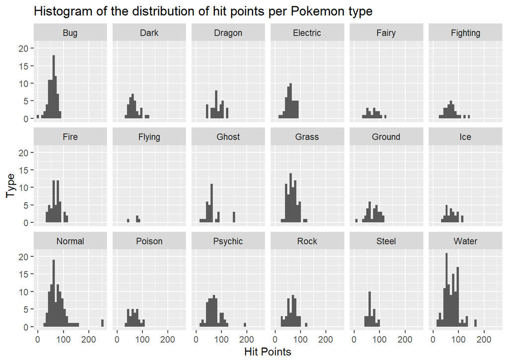

```r
# Insert your code here
ggplot(pokemon, aes(x=hp))+
  geom_histogram()+
  labs(x = "Hit Points", y = "Type", title = "Histogram of the distribution of hit points per Pokemon type")+
  facet_wrap(~ type1, nrow = 3)
```

## Q3 (5 points): What’s the correlation between attack and defense?

```r
# Insert your code here
pokemon %>% get_correlation(formula = attack ~ defense)
```

```
## # A tibble: 1 x 1
##     cor
##   <dbl>
## 1 0.439
```

## Q4: (5 points) Create a scatterplot with attack on the y (vertical) axis and defense on the x (horizontal) axis. Use R to draw a line through the data to show the relationship between attack and defense. Do not show standard error lines on the scatterplot.

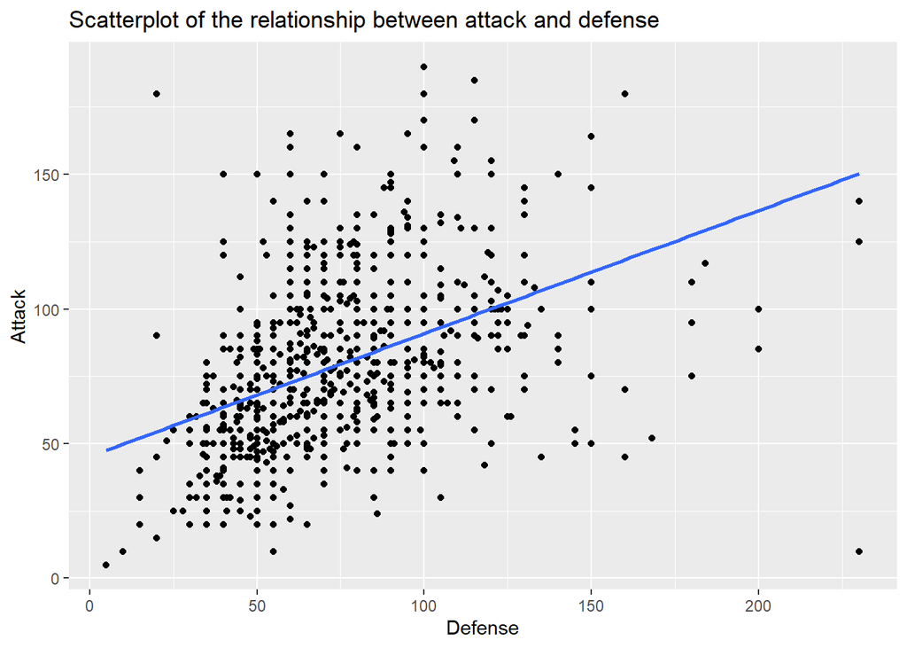

```r
# Insert your code here
ggplot(pokemon, aes(x = defense, y = attack))+
  geom_point()+
  labs(x = "Defense", y = "Attack", title = "Scatterplot of the relationship between attack and defense")+
  geom_smooth(method = "lm", se = FALSE)
```

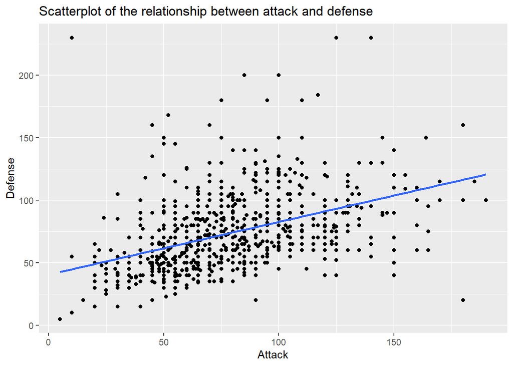

```r
ggplot(pokemon, aes(x = attack, y = defense))+
  geom_point()+
  labs(x = "Attack", y = "Defense", title = "Scatterplot of the relationship between attack and defense")+
  geom_smooth(method = "lm", se = FALSE)
```

## Q5 (5 points): Fit a regression that models attack as a function of defense.

```r
# Insert your code here
defense_model <- lm(defense ~ attack, data = pokemon)

get_regression_table(defense_model)
```

```
## # A tibble: 2 x 7
##   term      estimate std_error statistic p_value lower_ci upper_ci
##   <chr>        <dbl>     <dbl>     <dbl>   <dbl>    <dbl>    <dbl>
## 1 intercept   40.5       2.61       15.5       0   35.4     45.7
## 2 attack       0.421     0.031      13.8       0    0.361    0.481
```

## Q6 (5 points): Write out the equation that describes the relationship between attack and defense. Your answer should be of the form `attack = SOME_NUMBER + SOME_OTHER_NUMBER * defense`.

```r
# Insert your code here
get_regression_table(defense_model)
```

```
## # A tibble: 2 x 7
##   term      estimate std_error statistic p_value lower_ci upper_ci
##   <chr>        <dbl>     <dbl>     <dbl>   <dbl>    <dbl>    <dbl>
## 1 intercept   40.5       2.61       15.5       0   35.4     45.7
## 2 attack       0.421     0.031      13.8       0    0.361    0.481
```

## Q7 (5 points): How much of the total variance is explained by your model?

```r
# Insert your code here
get_regression_summaries(defense_model)
```

```
## # A tibble: 1 x 8
##   r_squared adj_r_squared   mse  rmse sigma statistic p_value    df
##       <dbl>         <dbl> <dbl> <dbl> <dbl>     <dbl>   <dbl> <dbl>
## 1     0.192         0.191  784.  28.0  28.0      190.       0     2
```

Insert your answer here. total variance = 0.19

## Q9 (5 points): You will notice that there’s one outlier that has an exceptionally large value for ‘defense’ and a very low value for ‘attack’. What’s the name of that pokemon character?

```r
# Insert your code here
max_def <- pokemon %>%
  arrange(desc(defense))
max_def
```

```
## # A tibble: 800 x 13
##    id_number name  type1 type2 total    hp attack defense sp_attack sp_defense
##        <dbl> <chr> <chr> <chr> <dbl> <dbl>  <dbl>   <dbl>     <dbl>      <dbl>
##  1       208 Stee~ Steel Grou~   610    75    125     230        55         95
##  2       213 Shuc~ Bug   Rock    505    20     10     230        10        230
##  3       306 Aggr~ Steel <NA>    630    70    140     230        60         80
##  4       208 Stee~ Steel Grou~   510    75     85     200        55         65
##  5       377 Regi~ Rock  <NA>    580    80    100     200        50        100
##  6       713 Aval~ Ice   <NA>    514    95    117     184        44         46
##  7        80 Slow~ Water Psyc~   590    95     75     180       130         80
##  8        91 Cloy~ Water Ice     525    50     95     180        85         45
##  9       306 Aggr~ Steel Rock    530    70    110     180        60         60
## 10       411 Bast~ Rock  Steel   495    60     52     168        47        138
## # ... with 790 more rows, and 3 more variables: speed <dbl>, generation <dbl>,
## #   legendary <lgl>
```

Insert your answer here. Shuckle

## Q10 (10 points): What’s a better predictor of hp: attack or defense? Justify your answer based on the output from your code.

```r
# Insert your code here
att_fit = lm(hp ~ attack, data=pokemon)
get_regression_summaries(att_fit)
```

```
## # A tibble: 1 x 8
##   r_squared adj_r_squared   mse  rmse sigma statistic p_value    df
##       <dbl>         <dbl> <dbl> <dbl> <dbl>     <dbl>   <dbl> <dbl>
## 1     0.178         0.177  535.  23.1  23.2      173.       0     2
```

```r
def_fit = lm(hp ~ defense, data=pokemon)
get_regression_summaries(def_fit)
```

```
## # A tibble: 1 x 8
##   r_squared adj_r_squared   mse  rmse sigma statistic p_value    df
##       <dbl>         <dbl> <dbl> <dbl> <dbl>     <dbl>   <dbl> <dbl>
## 1     0.057         0.056  614.  24.8  24.8      48.6       0     2
```

Insert your answer here. Attack power. In comparing the r_squared values from each of the models, we see the att_fit model accounts for 18% of the variance whereas the def_fit model only accounts for 6%.

## Q11 (5 points): What’s the expected value for hp, given a value of 80 for defense?

```r
# Insert your code here
defense_80 <- pokemon %>%
  filter(defense == 80) %>%
  skim()
defense_80
```

Data summary

| Name | Piped data |
| --- | --- |
| Number of rows | 39 |
| Number of columns | 13 |
| _______________________ |  |
| Column type frequency: |  |
| character | 3 |
| logical | 1 |
| numeric | 9 |
| ________________________ |  |
| Group variables | None |

**Variable type: character**

| skim_variable | n_missing | complete_rate | min | max | empty | n_unique | whitespace |
| --- | --- | --- | --- | --- | --- | --- | --- |
| name | 0 | 1.00 | 6 | 23 | 0 | 39 | 0 |
| type1 | 0 | 1.00 | 3 | 8 | 0 | 15 | 0 |
| type2 | 15 | 0.62 | 3 | 8 | 0 | 11 | 0 |

**Variable type: logical**

| skim_variable | n_missing | complete_rate | mean | count |
| --- | --- | --- | --- | --- |
| legendary | 0 | 1 | 0.05 | FAL: 37, TRU: 2 |

**Variable type: numeric**

| skim_variable | n_missing | complete_rate | mean | sd | p0 | p25 | p50 | p75 | p100 | hist |
| --- | --- | --- | --- | --- | --- | --- | --- | --- | --- | --- |
| id_number | 0 | 1 | 312.56 | 208.25 | 8 | 127.0 | 288 | 505.0 | 715 | ▇▆▅▅▅ |
| total | 0 | 1 | 495.87 | 73.20 | 300 | 465.0 | 490 | 535.0 | 630 | ▁▃▇▇▅ |
| hp | 0 | 1 | 83.51 | 21.45 | 40 | 71.0 | 80 | 92.5 | 165 | ▃▇▃▁▁ |
| attack | 0 | 1 | 92.87 | 26.97 | 40 | 75.0 | 90 | 112.5 | 160 | ▃▇▇▆▁ |
| defense | 0 | 1 | 80.00 | 0.00 | 80 | 80.0 | 80 | 80.0 | 80 | ▁▁▇▁▁ |
| sp_attack | 0 | 1 | 81.59 | 30.76 | 35 | 60.0 | 70 | 101.5 | 170 | ▇▇▃▃▁ |
| sp_defense | 0 | 1 | 77.26 | 14.51 | 45 | 75.0 | 80 | 80.0 | 110 | ▂▂▇▂▁ |
| speed | 0 | 1 | 80.64 | 29.76 | 30 | 56.5 | 80 | 100.0 | 135 | ▇▇▇▇▅ |
| generation | 0 | 1 | 2.87 | 1.59 | 1 | 1.0 | 3 | 4.5 | 6 | ▇▅▁▅▁ |

```r
Q11 <- lm(hp ~ defense, data=pokemon)
get_regression_table(Q11)
```

```
## # A tibble: 2 x 7
##   term      estimate std_error statistic p_value lower_ci upper_ci
##   <chr>        <dbl>     <dbl>     <dbl>   <dbl>    <dbl>    <dbl>
## 1 intercept   54.8       2.26      24.3        0   50.3     59.2
## 2 defense      0.196     0.028      6.97       0    0.141    0.251
```

```r
54.770 + 0.196 * 80
```

```
## [1] 70.45
```

```r
Q11.1 = lm(hp ~ attack + defense, data = pokemon)
get_regression_table(Q11.1)
```

```
## # A tibble: 3 x 7
##   term      estimate std_error statistic p_value lower_ci upper_ci
##   <chr>        <dbl>     <dbl>     <dbl>   <dbl>    <dbl>    <dbl>
## 1 intercept   40.8       2.46      16.6     0      36.0     45.6
## 2 attack       0.309     0.028     11.0     0       0.254    0.364
## 3 defense      0.055     0.029      1.89    0.06   -0.002    0.112
```

```r
get_regression_summaries(Q11.1)
```

```
## # A tibble: 1 x 8
##   r_squared adj_r_squared   mse  rmse sigma statistic p_value    df
##       <dbl>         <dbl> <dbl> <dbl> <dbl>     <dbl>   <dbl> <dbl>
## 1     0.182          0.18  533.  23.1  23.1      88.7       0     3
```

Insert your answer here. I tried a few things here to play with the data, but my variable Q11 provides a regression table that I then used to calculate an expected value of 70.45.

## Q12 (5 points): Create a boxplot that shows the distribution of values of speed for each different value of type1. Based on your boxplot, which type of pokemon character is fastest? Be sure to consider both measures of central tendency and dispersion in your answer.

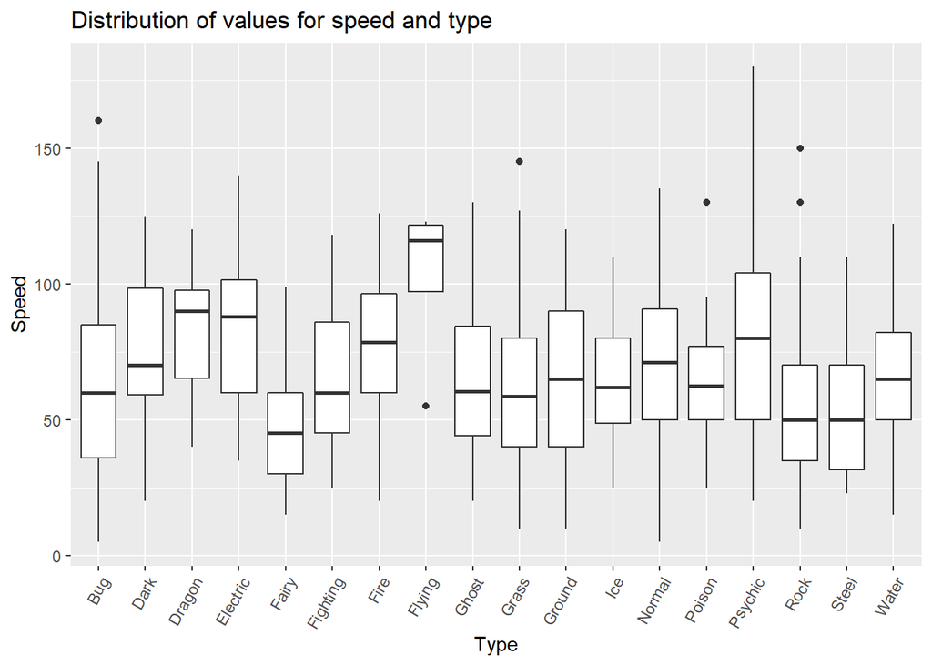

```r
# Insert your code here
ggplot(pokemon, aes(x = type1, y = speed))+
  geom_boxplot()+
  theme(axis.text.x = element_text(angle = 60, hjust = 1))+
  labs(x = "Type", y = "Speed", title = "Distribution of values for speed and type")
```

Insert your answer here. Flying pokemon are the fastest in a classical sense of the word, as in getting from point A to B. However, we notice a large maximum Q3 for Psychic Pokemon. My assumption is that this refers to some ability to teleport. We also see some outliers including type Bug, Grass, Poison, and Rock, where individual Pokemon of these types has a special characteristic which makes them particularly fast. What we can see from the boxplot is that with little exception, all flying Pokemon are among the fastest, and this is supported by a tight IQR with a median close to the 75th percentile. And that’s because all flying Pokemon can fly, but not all psychic Pokemon can teleport.

## Q13 (10 points): Fit a linear model of the explanatory variable ‘type1’ and the outcome variable ‘speed’.

```r
# Insert your code here
speed_model <- lm(speed ~ type1, data = pokemon)

get_regression_table(speed_model)
```

```
## # A tibble: 18 x 7
##    term          estimate std_error statistic p_value lower_ci upper_ci
##    <chr>            <dbl>     <dbl>     <dbl>   <dbl>    <dbl>    <dbl>
##  1 intercept       61.7        3.36    18.3     0        55.1     68.3
##  2 type1Dark       14.5        6.04     2.40    0.017     2.63    26.3
##  3 type1Dragon     21.4        5.97     3.57    0         9.62    33.1
##  4 type1Electric   22.8        5.39     4.24    0        12.2     33.4
##  5 type1Fairy     -13.1        7.56    -1.73    0.084   -27.9      1.75
##  6 type1Fighting    4.39       6.34     0.693   0.489    -8.05    16.8
##  7 type1Fire       12.8        5.13     2.49    0.013     2.69    22.8
##  8 type1Flying     40.8       14.4      2.84    0.005    12.6     69.0
##  9 type1Ghost       2.66       5.97     0.446   0.656    -9.06    14.4
## 10 type1Grass       0.247      4.74     0.052   0.958    -9.05     9.55
## 11 type1Ground      2.22       5.97     0.373   0.71     -9.5     14.0
## 12 type1Ice         1.78       6.62     0.269   0.788   -11.2     14.8
## 13 type1Normal      9.87       4.39     2.25    0.025     1.25    18.5
## 14 type1Poison      1.89       6.26     0.302   0.763   -10.4     14.2
## 15 type1Psychic    19.8        5.00     3.96    0        10.0     29.6
## 16 type1Rock       -5.77       5.39    -1.07    0.284   -16.3      4.80
## 17 type1Steel      -6.42       6.34    -1.01    0.311   -18.9      6.02
## 18 type1Water       4.28       4.27     1.00    0.317    -4.11    12.7
```

## Q14 (5 points): What’s the estimate for the mean value of speed for Fairy characters?

```r
# Insert your code here
type_fairy <- pokemon %>%
  filter(type1 == "Fairy")

fairy_speed <- type_fairy %>%
  skim(speed)
fairy_speed
```

Data summary

| Name | Piped data |
| --- | --- |
| Number of rows | 17 |
| Number of columns | 13 |
| _______________________ |  |
| Column type frequency: |  |
| numeric | 1 |
| ________________________ |  |
| Group variables | None |

**Variable type: numeric**

| skim_variable | n_missing | complete_rate | mean | sd | p0 | p25 | p50 | p75 | p100 | hist |
| --- | --- | --- | --- | --- | --- | --- | --- | --- | --- | --- |
| speed | 0 | 1 | 48.59 | 23.31 | 15 | 30 | 45 | 60 | 99 | ▇▆▆▅▂ |

Insert your answer here. Mean Fairy Pokemon speed = 48.6